# Data cleaning

```python
import numpy as np
import pandas as pd
from pathlib import Path
import seaborn as sns
import matplotlib.pyplot as plt
import plotly.express as px
from sklearn.preprocessing import StandardScaler
from sklearn.decomposition import PCA
```

```python
file_path= Path.cwd()
file_path
```

```
WindowsPath('c:/Users/komet/Data-Vis-CA1/Carlson')
```

Read CSV Files

```python
file_name="season-1920.csv"
data_19_20 = pd.read_csv(file_path / file_name)
file_name="season-2021.csv"
data_20_21 = pd.read_csv(file_path / file_name)
file_name="season-2122.csv"
data_21_22 = pd.read_csv(file_path / file_name)
```

Combine the data

```python
# Empty array
tables = []

tables = pd.concat([data_19_20, data_20_21, data_21_22])
tables=pd.DataFrame(tables)
tables
```

|  | Date | HomeTeam | AwayTeam | FTHG | FTAG | FTR | HTHG | HTAG | HTR | Referee | ... | HST | AST | HF | AF | HC | AC | HY | AY | HR | AR |
| --- | --- | --- | --- | --- | --- | --- | --- | --- | --- | --- | --- | --- | --- | --- | --- | --- | --- | --- | --- | --- | --- |
| 0 | 09/08/19 | Liverpool | Norwich | 4 | 1 | H | 4 | 0 | H | M Oliver | ... | 7 | 5 | 9 | 9 | 11 | 2 | 0 | 2 | 0 | 0 |
| 1 | 10/08/19 | West Ham | Man City | 0 | 5 | A | 0 | 1 | A | M Dean | ... | 3 | 9 | 6 | 13 | 1 | 1 | 2 | 2 | 0 | 0 |
| 2 | 10/08/19 | Bournemouth | Sheffield United | 1 | 1 | D | 0 | 0 | D | K Friend | ... | 3 | 3 | 10 | 19 | 3 | 4 | 2 | 1 | 0 | 0 |
| 3 | 10/08/19 | Burnley | Southampton | 3 | 0 | H | 0 | 0 | D | G Scott | ... | 4 | 3 | 6 | 12 | 2 | 7 | 0 | 0 | 0 | 0 |
| 4 | 10/08/19 | Crystal Palace | Everton | 0 | 0 | D | 0 | 0 | D | J Moss | ... | 2 | 3 | 16 | 14 | 6 | 2 | 2 | 1 | 0 | 1 |
| ... | ... | ... | ... | ... | ... | ... | ... | ... | ... | ... | ... | ... | ... | ... | ... | ... | ... | ... | ... | ... | ... |
| 375 | 22/05/22 | Crystal Palace | Man United | 1 | 0 | H | 1 | 0 | H | M Atkinson | ... | 3 | 4 | 12 | 22 | 3 | 6 | 2 | 4 | 0 | 0 |
| 376 | 22/05/22 | Leicester | Southampton | 4 | 1 | H | 0 | 0 | D | J Moss | ... | 6 | 2 | 10 | 5 | 3 | 3 | 0 | 1 | 0 | 0 |
| 377 | 22/05/22 | Liverpool | Wolves | 3 | 1 | H | 1 | 1 | D | A Taylor | ... | 8 | 5 | 6 | 3 | 5 | 3 | 1 | 0 | 0 | 0 |
| 378 | 22/05/22 | Man City | Aston Villa | 3 | 2 | H | 0 | 1 | A | M Oliver | ... | 5 | 2 | 5 | 11 | 13 | 1 | 0 | 1 | 0 | 0 |
| 379 | 22/05/22 | Norwich | Tottenham | 0 | 5 | A | 0 | 2 | A | C Kavanagh | ... | 0 | 13 | 13 | 7 | 3 | 2 | 3 | 1 | 0 | 0 |

1140 rows × 22 columns

seperate Home teams from Away teams

Get home team data

```python
home = pd.DataFrame({
    "team": tables["HomeTeam"],
    "matches": 1,
    "goals": tables["FTHG"],
    "wins": (tables["FTR"] == "H").astype(int),
    "draws": (tables["FTR"] == "D").astype(int),
    "losses": (tables["FTR"] == "A").astype(int),

    "halftime_goals": tables["HTHG"],
    "halftime_wins": (tables["HTR"] == "H").astype(int),
    "halftime_draws": (tables["HTR"] == "D").astype(int),
    "halftime_losses": (tables["HTR"] == "A").astype(int),

    "shots": tables["HS"],
    "shots_on_target": tables["HST"],
    "fouls_commited": tables["HF"],
    "corners": tables["HC"],
    "yellow_cards": tables["HY"],
    "red_cards": tables["HR"]
})
```

Get away team data

```python
away = pd.DataFrame({
    "team": tables["AwayTeam"],
    "matches": 1,
    "goals": tables["FTAG"],
    "wins": (tables["FTR"] == "A").astype(int),
    "draws": (tables["FTR"] == "D").astype(int),
    "losses": (tables["FTR"] == "H").astype(int),

    "halftime_goals": tables["HTAG"],
    "halftime_wins": (tables["HTR"] == "A").astype(int),
    "halftime_draws": (tables["HTR"] == "D").astype(int),
    "halftime_losses": (tables["HTR"] == "H").astype(int),

    "shots": tables["AS"],
    "shots_on_target": tables["AST"],
    "fouls_commited": tables["AF"],
    "corners": tables["AC"],
    "yellow_cards": tables["AY"],
    "red_cards": tables["AR"]
})
```

Concatenate home team and away team data

```python
fixtures_results = pd.concat([home, away])
```

Save fixtures data as CSV file

```python
fixtures_results.to_csv('fixtures.csv', index=False)
```

```python
fixtures_results
```

|  | team | matches | goals | wins | draws | losses | halftime_goals | halftime_wins | halftime_draws | halftime_losses | shots | shots_on_target | fouls_commited | corners | yellow_cards | red_cards |
| --- | --- | --- | --- | --- | --- | --- | --- | --- | --- | --- | --- | --- | --- | --- | --- | --- |
| 0 | Liverpool | 1 | 4 | 1 | 0 | 0 | 4 | 1 | 0 | 0 | 15 | 7 | 9 | 11 | 0 | 0 |
| 1 | West Ham | 1 | 0 | 0 | 0 | 1 | 0 | 0 | 0 | 1 | 5 | 3 | 6 | 1 | 2 | 0 |
| 2 | Bournemouth | 1 | 1 | 0 | 1 | 0 | 0 | 0 | 1 | 0 | 13 | 3 | 10 | 3 | 2 | 0 |
| 3 | Burnley | 1 | 3 | 1 | 0 | 0 | 0 | 0 | 1 | 0 | 10 | 4 | 6 | 2 | 0 | 0 |
| 4 | Crystal Palace | 1 | 0 | 0 | 1 | 0 | 0 | 0 | 1 | 0 | 6 | 2 | 16 | 6 | 2 | 0 |
| ... | ... | ... | ... | ... | ... | ... | ... | ... | ... | ... | ... | ... | ... | ... | ... | ... |
| 375 | Man United | 1 | 0 | 0 | 0 | 1 | 0 | 0 | 0 | 1 | 10 | 4 | 22 | 6 | 4 | 0 |
| 376 | Southampton | 1 | 1 | 0 | 0 | 1 | 0 | 0 | 1 | 0 | 7 | 2 | 5 | 3 | 1 | 0 |
| 377 | Wolves | 1 | 1 | 0 | 0 | 1 | 1 | 0 | 1 | 0 | 7 | 5 | 3 | 3 | 0 | 0 |
| 378 | Aston Villa | 1 | 2 | 0 | 0 | 1 | 1 | 1 | 0 | 0 | 4 | 2 | 11 | 1 | 1 | 0 |
| 379 | Tottenham | 1 | 5 | 1 | 0 | 0 | 2 | 1 | 0 | 0 | 19 | 13 | 7 | 2 | 1 | 0 |

2280 rows × 16 columns

Sum each team's values

```python
combined_data = fixtures_results.groupby("team").sum().reset_index()
```

Display sample of data

```python
combined_data.head()
```

|  | team | matches | goals | wins | draws | losses | halftime_goals | halftime_wins | halftime_draws | halftime_losses | shots | shots_on_target | fouls_commited | corners | yellow_cards | red_cards |
| --- | --- | --- | --- | --- | --- | --- | --- | --- | --- | --- | --- | --- | --- | --- | --- | --- |
| 0 | Arsenal | 114 | 172 | 54 | 24 | 36 | 87 | 42 | 40 | 32 | 1457 | 500 | 1129 | 648 | 193 | 14 |
| 1 | Aston Villa | 114 | 148 | 38 | 21 | 55 | 66 | 37 | 43 | 34 | 1424 | 499 | 1291 | 611 | 208 | 6 |
| 2 | Bournemouth | 38 | 40 | 9 | 7 | 22 | 20 | 7 | 13 | 18 | 389 | 121 | 369 | 194 | 73 | 3 |
| 3 | Brentford | 38 | 48 | 13 | 7 | 18 | 16 | 7 | 15 | 16 | 442 | 154 | 371 | 159 | 61 | 3 |
| 4 | Brighton | 114 | 121 | 30 | 43 | 41 | 50 | 31 | 44 | 39 | 1438 | 437 | 1205 | 599 | 172 | 10 |

Check for missing values

```python
combined_data.isna().sum()
```

```
team               0
matches            0
goals              0
wins               0
draws              0
losses             0
halftime_goals     0
halftime_wins      0
halftime_draws     0
halftime_losses    0
shots              0
shots_on_target    0
fouls_commited     0
corners            0
yellow_cards       0
red_cards          0
dtype: int64
```

Get Refree data, using group by

```python
tables['TotalGoals'] = tables['FTHG'] + tables['FTAG']
tables['TotalFouls'] = tables['HF'] + tables['AF']
tables['TotalYellow'] = tables['HY'] + tables['AY']
tables['TotalRed'] = tables['HR'] + tables['AR']

ref_summary = tables.groupby('Referee').agg(
    Matches=('Date', 'count'),
    Goals=('TotalGoals', 'sum'),
    Fouls=('TotalFouls', 'sum'),
    Yellow_Cards=('TotalYellow', 'sum'),
    Red_Cards=('TotalRed', 'sum'),
    Home_Win_Pct=('FTR', lambda x: (x == 'H').mean()),
    Away_Win_Pct=('FTR', lambda x: (x == 'A').mean())
).reset_index()
```

Display sample data

```python
ref_summary.head()
```

|  | Referee | Matches | Goals | Fouls | Yellow_Cards | Red_Cards | Home_Win_Pct | Away_Win_Pct |
| --- | --- | --- | --- | --- | --- | --- | --- | --- |
| 0 | A Madley | 43 | 119 | 1018 | 115 | 4 | 0.441860 | 0.302326 |
| 1 | A Marriner | 68 | 196 | 1245 | 179 | 5 | 0.323529 | 0.397059 |
| 2 | A Moss | 1 | 1 | 20 | 4 | 0 | 0.000000 | 1.000000 |
| 3 | A Taylor | 88 | 257 | 1789 | 297 | 13 | 0.443182 | 0.318182 |
| 4 | C Kavanagh | 66 | 180 | 1419 | 216 | 6 | 0.454545 | 0.333333 |

check for missing data in referees table

```python
ref_summary.isna().sum()
```

```
Referee         0
Matches         0
Goals           0
Fouls           0
Yellow_Cards    0
Red_Cards       0
Home_Win_Pct    0
Away_Win_Pct    0
dtype: int64
```

save referees and teams data as csv files

```python
combined_data.to_csv('teams_summary.csv', index=False)
ref_summary.to_csv('ref_summary.csv', index=False)
```

```python
numeric_cols = combined_data.select_dtypes(include=[np.number]).columns
```

Univariate analysis

Check for numerical values distribution for teams

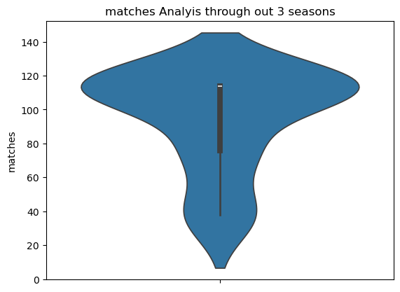

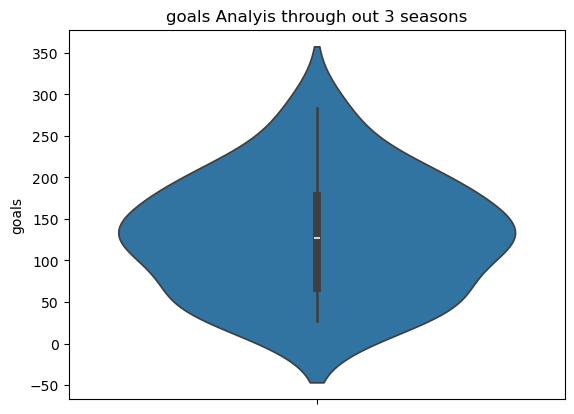

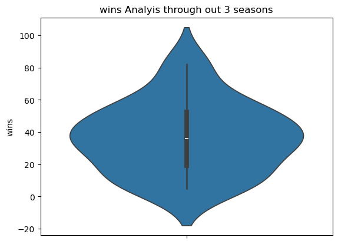

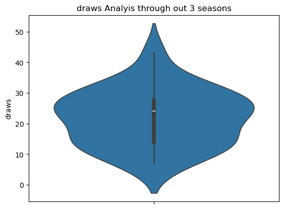

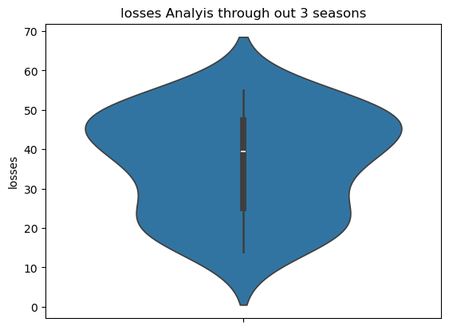

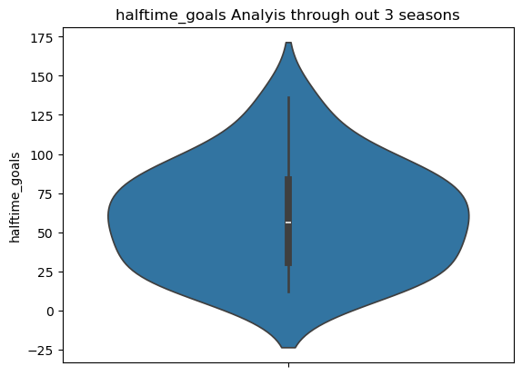

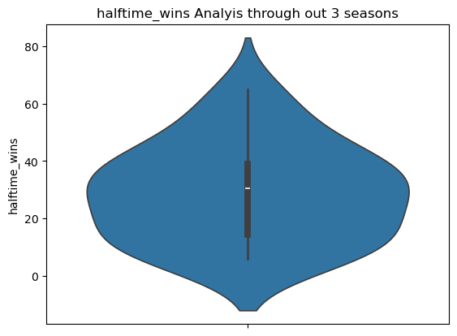

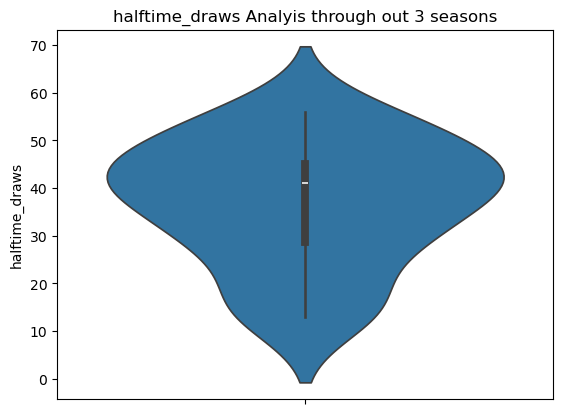

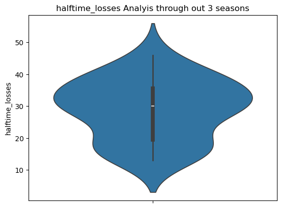

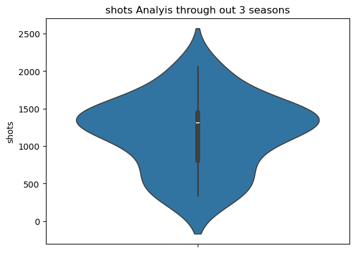

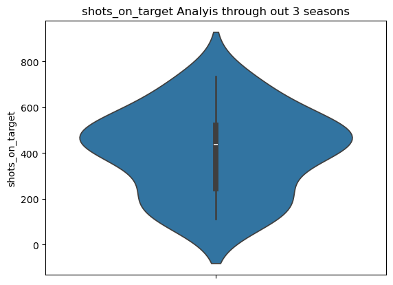

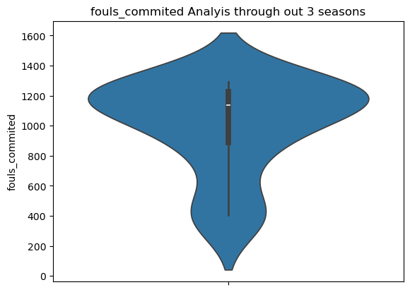

[3 more figures not shown]

```python
for col in numeric_cols:
    sns.violinplot(y=combined_data[col])
    name= col  + " Analyis through out 3 seasons"
    plt.title(name)
    plt.figure(figsize=(8, 8))
    plt.show()
```

```python
numeric_cols = ref_summary.select_dtypes(include=[np.number]).columns
```

Distribution of referee statistics

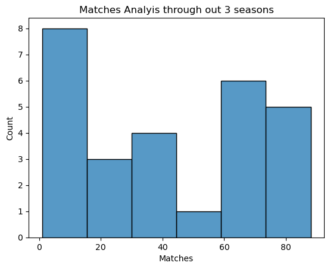

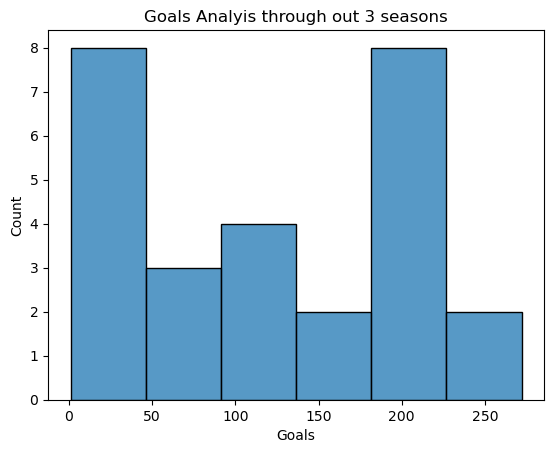

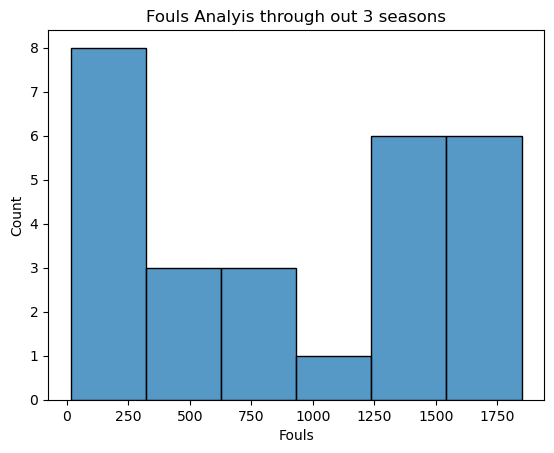

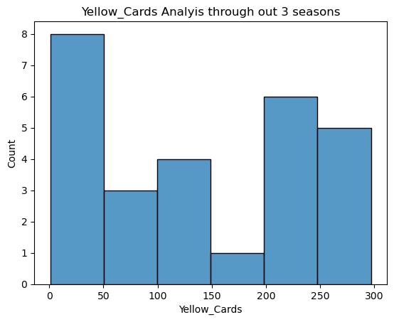

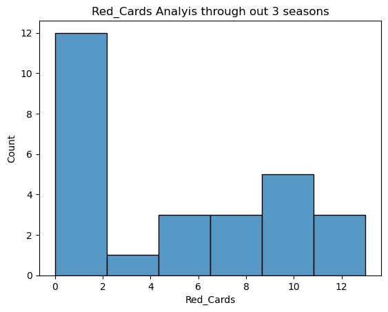

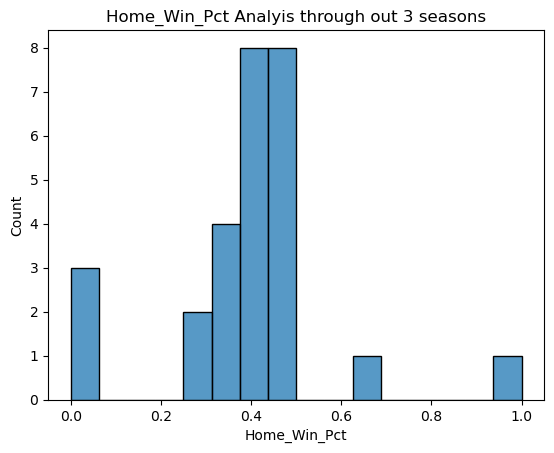

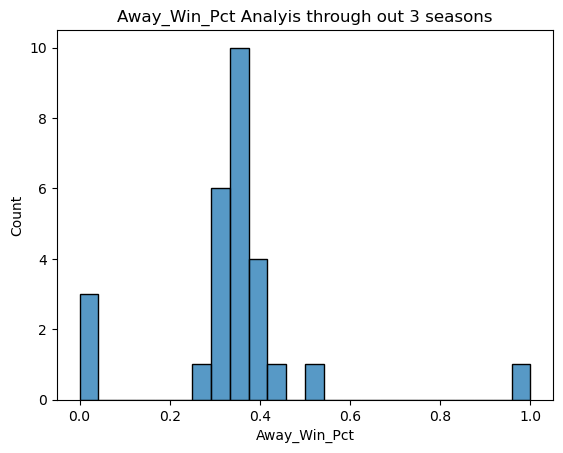

```python
for col in numeric_cols:
    sns.histplot(ref_summary[col])
    name= col  + " Analyis through out 3 seasons"
    plt.title(name)
    plt.figure(figsize=(8, 8))
    plt.show()
```

checking the number of matches played by each team

```python
fig = px.histogram(fixtures_results, x='team', color='team',
             title='Matches Played distribution '
             )

# Show the plot
fig.show()
```

[output not shown]

checking the number of matches Refereed by each referee

```python
fig = px.histogram(tables, x='Referee', color='Referee',
             title='Matches Refereed distribution'
             )

# Show the plot
fig.show()
```

[output not shown]

Multivariate and Bivariate analysis

investigating the relationship other values have with goals

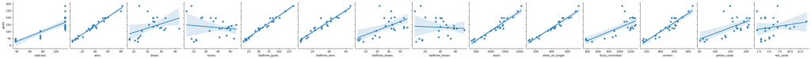

```python
numeric_df = combined_data.select_dtypes(include=[np.number])
sns.pairplot(
    numeric_df,
    x_vars=[col for col in numeric_df.columns if col != "goals"],
    y_vars=["goals"],
    kind="reg",
    height=3,
    aspect=1
)

plt.show()
```

```python
fig = px.box(fixtures_results, x='team', y="goals", color='team',
             title='goals per match vs teams '
             )

# Show the plot
fig.show()
```

[output not shown]

Investigating how goals can influence wins

```python
fig = px.scatter(data_frame=combined_data, x="wins", y="goals",  title="wins vs goals",
            size="losses", color="team", hover_name="team",
            hover_data=['wins','draws','losses', 'yellow_cards', 'halftime_wins']
)
fig.show()
```

[output not shown]

Investigating how Fouls can influence Cards

```python
fig = px.scatter(data_frame=ref_summary, x="Yellow_Cards", y="Fouls",  title="wins vs goals",
            size="Red_Cards", color="Referee", hover_name="Referee",
            hover_data=['Matches','Home_Win_Pct','Away_Win_Pct']
)
fig.show()
```

[output not shown]

# PCA

```python
temp=combined_data
X = temp.drop(columns=["team"])
```

```python
scaler = StandardScaler()
X_scaled = scaler.fit_transform(X)
```

```python
pca = PCA(n_components=2)   # reduce to 2 components for visualization
principal_components = pca.fit_transform(X_scaled)

pca_df = pd.DataFrame(
    principal_components,
    columns=["PC1", "PC2"]
)

pca_df["team"] = temp["team"]
```

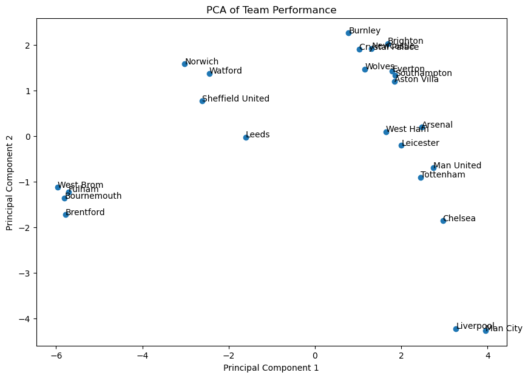

```python
plt.figure(figsize=(10, 7))

plt.scatter(pca_df["PC1"], pca_df["PC2"])

for i, team in enumerate(pca_df["team"]):
    plt.text(pca_df["PC1"][i], pca_df["PC2"][i], team)

plt.xlabel("Principal Component 1")
plt.ylabel("Principal Component 2")
plt.title("PCA of Team Performance")
plt.show()
```

PCA Loadings

```python
loadings = pd.DataFrame(
    pca.components_.T,
    columns=["PC1", "PC2"],
    index=X.columns
)

print(loadings)
```

```
                      PC1       PC2
matches          0.308187  0.120542
goals            0.285844 -0.230193
wins             0.282286 -0.241738
draws            0.222484  0.265437
losses           0.076910  0.499627
halftime_goals   0.281989 -0.232146
halftime_wins    0.282753 -0.219696
halftime_draws   0.261532  0.202894
halftime_losses  0.101269  0.496675
shots            0.305719 -0.117244
shots_on_target  0.302469 -0.151910
fouls_commited   0.294750  0.175720
corners          0.305006 -0.098075
yellow_cards     0.266504  0.233051
red_cards        0.119212  0.179773
```

```python
print(pca.explained_variance_ratio_)
```

```
[0.66326251 0.21523244]
```

- PC1 explains 66.33% of the total variance
- PC2 explains 21.52% of the total variance

PC1 represents overall team activity and competitive intensity, capturing 66% of variance. PC2 represents performance success, separating winning teams from losing teams. Together, the two components explain nearly 88% of total variation, meaning team performance can largely be summarized along strength and success dimensions

```python
temp_ref=ref_summary
X = temp_ref.drop(columns=["Referee"])
```

```python
scaler = StandardScaler()
X_scaled = scaler.fit_transform(X)
```

```python
pca = PCA(n_components=2)   # reduce to 2 components for visualization
principal_components = pca.fit_transform(X_scaled)

pca_df = pd.DataFrame(
    principal_components,
    columns=["PC1", "PC2"]
)

pca_df["Referee"] = temp_ref["Referee"]
```

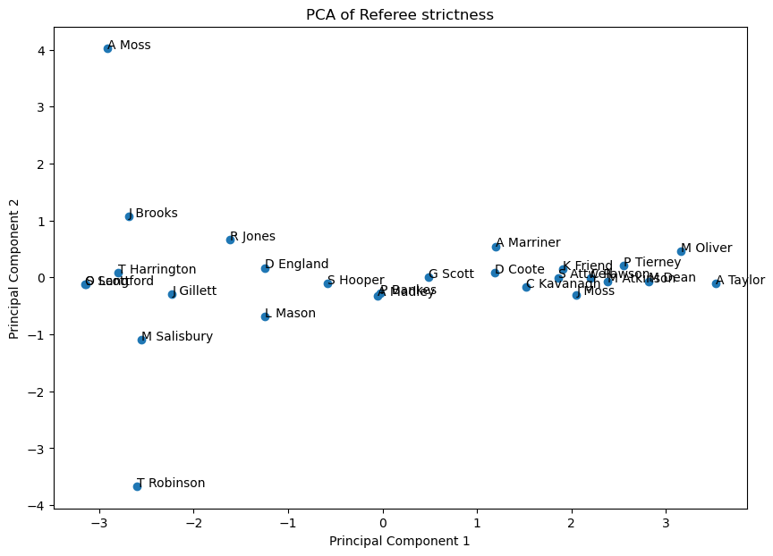

```python
plt.figure(figsize=(10, 7))

plt.scatter(pca_df["PC1"], pca_df["PC2"])

for i, team in enumerate(pca_df["Referee"]):
    plt.text(pca_df["PC1"][i], pca_df["PC2"][i], team)

plt.xlabel("Principal Component 1")
plt.ylabel("Principal Component 2")
plt.title("PCA of Referee strictness")
plt.show()
```

PCA loadings

```python
loadings = pd.DataFrame(
    pca.components_.T,
    columns=["PC1", "PC2"],
    index=X.columns
)

print(loadings)
```

```
                   PC1       PC2
Matches       0.449496  0.019993
Goals         0.446846  0.020834
Fouls         0.449118  0.015468
Yellow_Cards  0.447142  0.019222
Red_Cards     0.428898  0.016893
Home_Win_Pct  0.104699 -0.681995
Away_Win_Pct  0.041525  0.730175
```

```python
print(pca.explained_variance_ratio_)
```

```
[0.69679851 0.17974695]
```

- PC1 (69.7%) = Overall officiating intensity / strictness
- PC2 (18%) = Home-dominant vs Away-dominant match outcomes
- Together, these two dimensions explain nearly 88% of variation, meaning referee differences are mainly about how active/strict they are and secondarily about home vs away outcome patterns.